# R: (Generalized) Simultaneous Item Bias Test (SIBTEST)

| SIBTEST {mirt} | R Documentation |
| --- | --- |

## (Generalized) Simultaneous Item Bias Test (SIBTEST)

### Description

Classical test theory approach to detecting unidirectional and bidirectional (with one crossing location) DIF. This family of statistics is intended for unidimensional tests, and applies a regression-corrected matched-total score approach to quantify the response bias between two or more groups. Can be used for DIF, DBF, and DTF testing with two or more discrete groups.

### Usage

```r
SIBTEST(
  dat,
  group,
  suspect_set,
  match_set,
  focal_name = unique(group)[2],
  guess_correction = 0,
  Jmin = 5,
  na.rm = FALSE,
  randomize = FALSE,
  C = cbind(1, -diag(length(unique(group)) - 1L)),
  pairwise = FALSE,
  DIF = FALSE,
  p.adjust.method = "none",
  permute = 1000,
  pk_focal = FALSE,
  correction = TRUE,
  remove_cross = FALSE,
  details = FALSE,
  plot = "none",
  ...
)
```

### Arguments

[output not shown]

### Details

SIBTEST is similar to the Mantel-Haenszel approach for detecting DIF but uses a regression correction based on the KR-20/coefficient alpha reliability index to correct the observed differences when the latent trait distributions are not equal. Function supports the standard SIBTEST for dichotomous and polytomous data (compensatory) and supports crossing DIF testing (i.e., non-compensatory/non-uniform) using the asymptotic sampling distribution version of the Crossing-SIBTEST (CSIBTEST) statistic described by Chalmers (2018) and the permutation method described by Li and Stout (1996). This function also supports the multi-group generalizations (GSIBTEST and GCSIBTEST) proposed by Chalmers and Zheng (2023), where users may specify alternative contrast matrices to evaluate specific comparisons between groups as well as perform joint hypothesis tests.

### Author(s)

Phil Chalmers rphilip.chalmers@gmail.com

### References

Chalmers, R. P. (2018). Improving the Crossing-SIBTEST statistic for detecting non-uniform DIF. *Psychometrika, 83*, 2, 376-386.

Chalmers, R., P. (2012). mirt: A Multidimensional Item Response Theory Package for the R Environment. *Journal of Statistical Software, 48*(6), 1-29. [doi:10.18637/jss.v048.i06](https://doi.org/10.18637/jss.v048.i06)

Chalmers, R. P. & Zheng, G. (2023). Multi-group Generalizations of SIBTEST and Crossing-SIBTEST. *Applied Measurement in Education, 36*(2), 171-191, [doi:10.1080/08957347.2023.2201703](https://doi.org/10.1080/08957347.2023.2201703).

Chang, H. H., Mazzeo, J. & Roussos, L. (1996). DIF for Polytomously Scored Items: An Adaptation of the SIBTEST Procedure. *Journal of Educational Measurement, 33*, 333-353.

Li, H.-H. & Stout, W. (1996). A new procedure for detection of crossing DIF. *Psychometrika, 61*, 647-677.

Shealy, R. & Stout, W. (1993). A model-based standardization approach that separates true bias/DIF from group ability differences and detect test bias/DTF as well as item bias/DIF. *Psychometrika, 58*, 159-194.

### Examples

```r
## No test:

set.seed(1234)
n <- 30
N <- 500
a <- matrix(1, n)
d <- matrix(rnorm(n), n)
group <- c(rep('reference', N), rep('focal', N*2))

## -------------
# groups completely equal
dat1 <- simdata(a, d, N, itemtype = 'dich')
dat2 <- simdata(a, d, N*2, itemtype = 'dich')
dat <- rbind(dat1, dat2)

# DIF (all other items as anchors)
SIBTEST(dat, group, suspect_set = 6)
```

```
##          focal_group n_matched_set n_suspect_set   beta    SE    X2 df     p
## SIBTEST        focal            29             1 -0.014 0.027 0.265  1 0.606
## CSIBTEST       focal            29             1 -0.015    NA 0.331  2 0.848
```

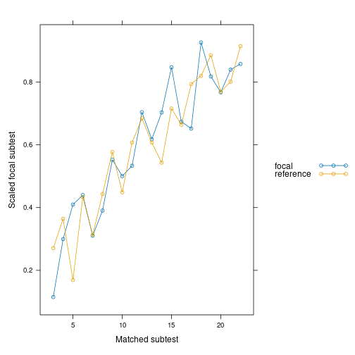

```r
# Some plots depicting the above tests
SIBTEST(dat, group, suspect_set = 6, plot = 'observed')
```

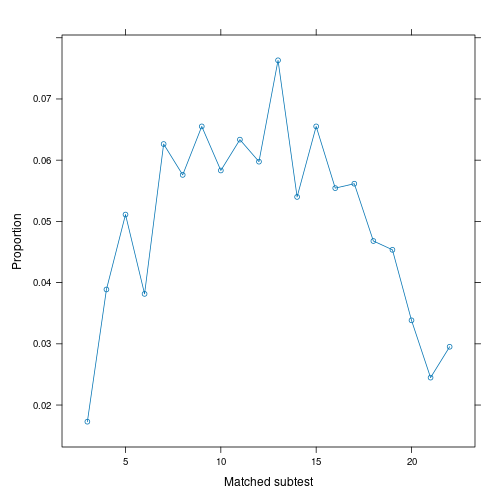

```r
SIBTEST(dat, group, suspect_set = 6, plot = 'weights')
```

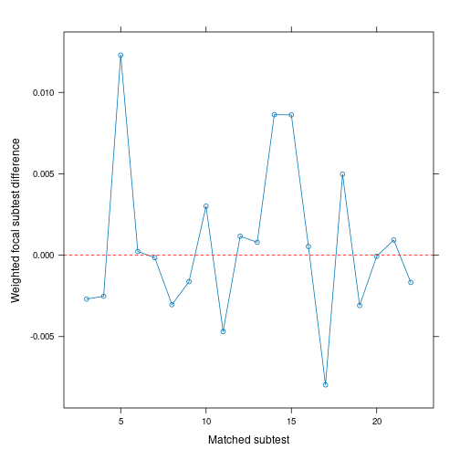

```r
SIBTEST(dat, group, suspect_set = 6, plot = 'wdifference')
```

```r
# Include CSIBTEST with randomization method
SIBTEST(dat, group, suspect_set = 6, randomize = TRUE)
```

```
##          focal_group n_matched_set n_suspect_set   beta    SE    X2 df     p
## SIBTEST        focal            29             1 -0.014 0.027 0.265  1 0.606
## CSIBTEST       focal            29             1 -0.015 0.027          0.827
```

```r
# remove crossing-location (identical to Li and Stout 1996 definition of CSIBTEST)
SIBTEST(dat, group, suspect_set = 6, randomize = TRUE, remove_cross=TRUE)
```

```
##          focal_group n_matched_set n_suspect_set   beta    SE    X2 df     p
## SIBTEST        focal            29             1 -0.014 0.027 0.265  1 0.606
## CSIBTEST       focal            29             1 -0.016 0.026          0.781
```

```r
# DIF (specific anchors)
SIBTEST(dat, group, match_set = 1:5, suspect_set = 6)
```

```
##          focal_group n_matched_set n_suspect_set   beta    SE    X2 df     p
## SIBTEST        focal             5             1 -0.008 0.028 0.078  1 0.781
## CSIBTEST       focal             5             1 -0.004    NA 0.105  2 0.949
```

```r
SIBTEST(dat, group, match_set = 1:5, suspect_set = 6, randomize=TRUE)
```

```
##          focal_group n_matched_set n_suspect_set   beta    SE    X2 df     p
## SIBTEST        focal             5             1 -0.008 0.028 0.078  1 0.781
## CSIBTEST       focal             5             1 -0.004 0.028              1
```

```r
# DBF (all and specific anchors, respectively)
SIBTEST(dat, group, suspect_set = 11:30)
```

```
##          focal_group n_matched_set n_suspect_set   beta    SE    X2 df    p
## SIBTEST        focal            10            20  0.053 0.165 0.102  1 0.75
## CSIBTEST       focal            10            20 -0.053    NA 0.102  1 0.75
```

```r
SIBTEST(dat, group, match_set = 1:5, suspect_set = 11:30)
```

```
##          focal_group n_matched_set n_suspect_set   beta    SE    X2 df   p
## SIBTEST        focal             5            20  0.166 0.197 0.708  1 0.4
## CSIBTEST       focal             5            20 -0.166    NA 0.708  1 0.4
```

```r
# DTF
SIBTEST(dat, group, suspect_set = 11:30)
```

```
##          focal_group n_matched_set n_suspect_set   beta    SE    X2 df    p
## SIBTEST        focal            10            20  0.053 0.165 0.102  1 0.75
## CSIBTEST       focal            10            20 -0.053    NA 0.102  1 0.75
```

```r
SIBTEST(dat, group, match_set = 1:10) #equivalent
```

```
##          focal_group n_matched_set n_suspect_set   beta    SE    X2 df    p
## SIBTEST        focal            10            20  0.053 0.165 0.102  1 0.75
## CSIBTEST       focal            10            20 -0.053    NA 0.102  1 0.75
```

```r
# different hyper pars
dat1 <- simdata(a, d, N, itemtype = 'dich')
dat2 <- simdata(a, d, N*2, itemtype = 'dich', mu = .5, sigma = matrix(1.5))
dat <- rbind(dat1, dat2)
SIBTEST(dat, group, 6:30)
```

```
##          focal_group n_matched_set n_suspect_set  beta    SE    X2 df     p
## SIBTEST        focal             5            25 0.115 0.249 0.214  1 0.644
## CSIBTEST       focal             5            25 0.419    NA 2.966  2 0.227
```

```r
SIBTEST(dat, group, 11:30)
```

```
##          focal_group n_matched_set n_suspect_set  beta    SE    X2 df     p
## SIBTEST        focal            10            20 0.098 0.171 0.333  1 0.564
## CSIBTEST       focal            10            20 0.321    NA 3.603  2 0.165
```

```r
# DIF testing with anchors 1 through 5
SIBTEST(dat, group, 6, match_set = 1:5)
```

```
##          focal_group n_matched_set n_suspect_set  beta    SE    X2 df     p
## SIBTEST        focal             5             1 0.012 0.027  0.18  1 0.671
## CSIBTEST       focal             5             1 0.030    NA 1.246  2 0.536
```

```r
SIBTEST(dat, group, 7, match_set = 1:5)
```

```
##          focal_group n_matched_set n_suspect_set   beta    SE    X2 df     p
## SIBTEST        focal             5             1 -0.011 0.029 0.148  1   0.7
## CSIBTEST       focal             5             1  0.038    NA 1.764  2 0.414
```

```r
SIBTEST(dat, group, 8, match_set = 1:5)
```

```
##          focal_group n_matched_set n_suspect_set   beta    SE    X2 df     p
## SIBTEST        focal             5             1 -0.026 0.028 0.824  1 0.364
## CSIBTEST       focal             5             1 -0.026    NA 0.824  1 0.364
```

```r
# DIF testing with all other items as anchors
SIBTEST(dat, group, 6)
```

```
##          focal_group n_matched_set n_suspect_set   beta    SE    X2 df     p
## SIBTEST        focal            29             1 -0.003 0.027 0.012  1 0.913
## CSIBTEST       focal            29             1  0.014    NA 0.261  2 0.878
```

```r
SIBTEST(dat, group, 7)
```

```
##          focal_group n_matched_set n_suspect_set   beta    SE    X2 df     p
## SIBTEST        focal            29             1 -0.014 0.028 0.241  1 0.623
## CSIBTEST       focal            29             1  0.032    NA 1.311  2 0.519
```

```r
SIBTEST(dat, group, 8)
```

```
##          focal_group n_matched_set n_suspect_set   beta    SE    X2 df     p
## SIBTEST        focal            29             1 -0.045 0.026 2.883  1 0.089
## CSIBTEST       focal            29             1 -0.045    NA 2.883  1 0.089
```

```r
## -------------
## systematic differing slopes and intercepts (clear DTF)
dat1 <- simdata(a, d, N, itemtype = 'dich')
dat2 <- simdata(a + c(numeric(15), rnorm(n-15, 1, .25)), d + c(numeric(15), rnorm(n-15, 1, 1)),
  N*2, itemtype = 'dich')
dat <- rbind(dat1, dat2)
SIBTEST(dat, group, 6:30)
```

```
##          focal_group n_matched_set n_suspect_set   beta    SE     X2 df p
## SIBTEST        focal             5            25 -2.334 0.264 78.065  1 0
## CSIBTEST       focal             5            25  2.334    NA 78.065  1 0
```

```r
SIBTEST(dat, group, 11:30)
```

```
##          focal_group n_matched_set n_suspect_set   beta    SE      X2 df p
## SIBTEST        focal            10            20 -2.376 0.179 176.396  1 0
## CSIBTEST       focal            10            20  2.376    NA 176.396  1 0
```

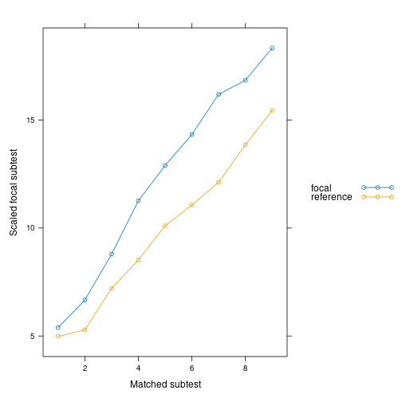

```r
# Some plots depicting the above tests
SIBTEST(dat, group, suspect_set = 11:30, plot = 'observed')
```

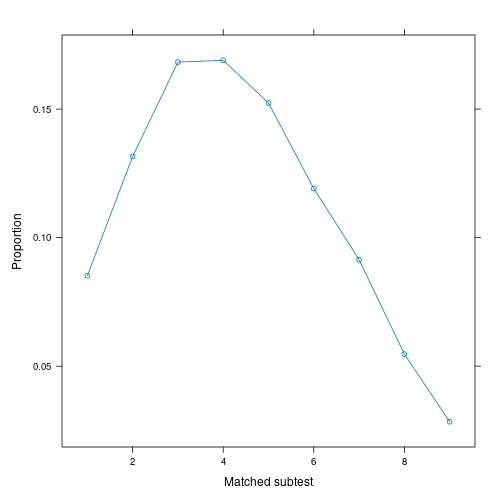

```r
SIBTEST(dat, group, suspect_set = 11:30, plot = 'weights')
```

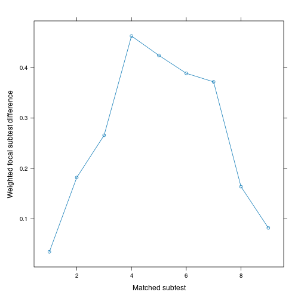

```r
SIBTEST(dat, group, suspect_set = 11:30, plot = 'wdifference')
```

```r
# DIF testing using valid anchors
SIBTEST(dat, group, suspect_set = 6, match_set = 1:5)
```

```
##          focal_group n_matched_set n_suspect_set   beta    SE    X2 df     p
## SIBTEST        focal             5             1 -0.013 0.028 0.209  1 0.648
## CSIBTEST       focal             5             1  0.060    NA 5.276  2 0.071
```

```r
SIBTEST(dat, group, suspect_set = 7, match_set = 1:5)
```

```
##          focal_group n_matched_set n_suspect_set   beta    SE    X2 df     p
## SIBTEST        focal             5             1  0.011 0.027  0.17  1  0.68
## CSIBTEST       focal             5             1 -0.006    NA 0.173  2 0.917
```

```r
SIBTEST(dat, group, suspect_set = 30, match_set = 1:5)
```

```
##          focal_group n_matched_set n_suspect_set   beta    SE      X2 df p
## SIBTEST        focal             5             1 -0.335 0.026 166.911  1 0
## CSIBTEST       focal             5             1  0.335    NA 166.911  1 0
```

```r
# test DIF using specific match_set
SIBTEST(dat, group, suspect_set = 6:30, match_set = 1:5, DIF=TRUE)
```

```
## $Item_6
##          focal_group n_matched_set n_suspect_set   beta    SE    X2 df     p
## SIBTEST        focal             5             1 -0.013 0.028 0.209  1 0.648
## CSIBTEST       focal             5             1  0.060    NA 5.276  2 0.071
##
## $Item_7
##          focal_group n_matched_set n_suspect_set   beta    SE    X2 df     p
## SIBTEST        focal             5             1  0.011 0.027  0.17  1  0.68
## CSIBTEST       focal             5             1 -0.006    NA 0.173  2 0.917
##
## $Item_8
##          focal_group n_matched_set n_suspect_set   beta    SE    X2 df    p
## SIBTEST        focal             5             1 -0.007 0.028 0.071  1 0.79
## CSIBTEST       focal             5             1  0.007    NA 0.071  1 0.79
##
## $Item_9
##          focal_group n_matched_set n_suspect_set   beta    SE    X2 df     p
## SIBTEST        focal             5             1  0.004 0.027 0.022  1 0.882
## CSIBTEST       focal             5             1 -0.020    NA 0.562  2 0.755
##
## $Item_10
##          focal_group n_matched_set n_suspect_set   beta    SE    X2 df     p
## SIBTEST        focal             5             1  0.031 0.027 1.309  1 0.253
## CSIBTEST       focal             5             1 -0.018    NA 1.314  2 0.518
##
## $Item_11
##          focal_group n_matched_set n_suspect_set   beta    SE    X2 df     p
## SIBTEST        focal             5             1  0.032 0.028 1.292  1 0.256
## CSIBTEST       focal             5             1 -0.032    NA 1.292  1 0.256
##
## $Item_12
##          focal_group n_matched_set n_suspect_set  beta    SE    X2 df     p
## SIBTEST        focal             5             1 0.018 0.026 0.448  1 0.503
## CSIBTEST       focal             5             1 0.010    NA 0.457  2 0.796
##
## $Item_13
##          focal_group n_matched_set n_suspect_set  beta    SE    X2 df     p
## SIBTEST        focal             5             1 0.000 0.027     0  1  0.99
## CSIBTEST       focal             5             1 0.029    NA 1.135  2 0.567
##
```

[output cut: 69 more lines]

```
##
## $Item_28
##          focal_group n_matched_set n_suspect_set   beta    SE      X2 df p
## SIBTEST        focal             5             1 -0.311 0.026 138.049  1 0
## CSIBTEST       focal             5             1  0.311    NA 138.049  1 0
##
## $Item_29
##          focal_group n_matched_set n_suspect_set   beta    SE     X2 df p
## SIBTEST        focal             5             1 -0.129 0.027 22.567  1 0
## CSIBTEST       focal             5             1  0.129    NA 22.567  1 0
##
## $Item_30
##          focal_group n_matched_set n_suspect_set   beta    SE      X2 df p
## SIBTEST        focal             5             1 -0.335 0.026 166.911  1 0
## CSIBTEST       focal             5             1  0.335    NA 166.911  1 0
```

```r
# test DIF using all-other-as-anchors method (not typically recommended)
SIBTEST(dat, group, suspect_set = 1:30, DIF=TRUE)
```

```
## $Item_1
##          focal_group n_matched_set n_suspect_set   beta    SE     X2 df p
## SIBTEST        focal            29             1  0.127 0.028 20.939  1 0
## CSIBTEST       focal            29             1 -0.127    NA 20.939  1 0
##
## $Item_2
##          focal_group n_matched_set n_suspect_set   beta    SE    X2 df     p
## SIBTEST        focal            29             1  0.048 0.029 2.801  1 0.094
## CSIBTEST       focal            29             1 -0.089    NA 9.376  2 0.009
##
## $Item_3
##          focal_group n_matched_set n_suspect_set  beta    SE   X2 df     p
## SIBTEST        focal            29             1 0.013 0.026 0.25  1 0.617
## CSIBTEST       focal            29             1 0.013    NA 0.25  1 0.617
##
## $Item_4
##          focal_group n_matched_set n_suspect_set   beta    SE    X2 df     p
## SIBTEST        focal            29             1  0.067 0.023 8.472  1 0.004
## CSIBTEST       focal            29             1 -0.067    NA 8.472  1 0.004
##
## $Item_5
##          focal_group n_matched_set n_suspect_set  beta    SE    X2 df     p
## SIBTEST        focal            29             1 0.054 0.028  3.78  1 0.052
## CSIBTEST       focal            29             1 0.071    NA 6.524  2 0.038
##
## $Item_6
##          focal_group n_matched_set n_suspect_set  beta    SE    X2 df     p
## SIBTEST        focal            29             1 0.045 0.027 2.839  1 0.092
## CSIBTEST       focal            29             1 0.047    NA 3.679  2 0.159
##
## $Item_7
##          focal_group n_matched_set n_suspect_set   beta    SE    X2 df     p
## SIBTEST        focal            29             1  0.082 0.028 8.455  1 0.004
## CSIBTEST       focal            29             1 -0.085    NA 9.148  2  0.01
##
## $Item_8
##          focal_group n_matched_set n_suspect_set   beta    SE     X2 df     p
## SIBTEST        focal            29             1  0.088 0.028 10.042  1 0.002
## CSIBTEST       focal            29             1 -0.108    NA 15.424  2     0
##
```

[output cut: 94 more lines]

```
##
## $Item_28
##          focal_group n_matched_set n_suspect_set   beta    SE     X2 df p
## SIBTEST        focal            29             1 -0.237 0.027 74.759  1 0
## CSIBTEST       focal            29             1  0.237    NA 74.759  1 0
##
## $Item_29
##          focal_group n_matched_set n_suspect_set   beta    SE     X2 df     p
## SIBTEST        focal            29             1 -0.036 0.027  1.744  1 0.187
## CSIBTEST       focal            29             1  0.105    NA 14.901  2 0.001
##
## $Item_30
##          focal_group n_matched_set n_suspect_set   beta    SE     X2 df p
## SIBTEST        focal            29             1 -0.264 0.028 87.158  1 0
## CSIBTEST       focal            29             1  0.264    NA 87.158  1 0
```

```r
# randomization method is fairly poor when smaller matched-set used
SIBTEST(dat, group, suspect_set = 30, match_set = 1:5, randomize=TRUE)
```

```
##          focal_group n_matched_set n_suspect_set   beta    SE      X2 df     p
## SIBTEST        focal             5             1 -0.335 0.026 166.911  1     0
## CSIBTEST       focal             5             1  0.335 0.026            0.253
```

```r
SIBTEST(dat, group, suspect_set = 30, randomize=TRUE)
```

```
##          focal_group n_matched_set n_suspect_set   beta    SE     X2 df p
## SIBTEST        focal            29             1 -0.264 0.028 87.158  1 0
## CSIBTEST       focal            29             1  0.264 0.028           0
```

```r
## ----------------------------------
# three group SIBTEST test
set.seed(1234)
n <- 30
N <- 1000
a <- matrix(1, n)
d <- matrix(rnorm(n), n)
group <- c(rep('group1', N), rep('group2', N), rep('group3', N))

# groups completely equal
dat1 <- simdata(a, d, N, itemtype = 'dich')
dat2 <- simdata(a, d, N, itemtype = 'dich')
dat3 <- simdata(a, d, N, itemtype = 'dich')
dat <- rbind(dat1, dat2, dat3)

# omnibus test using effects-coding contrast matrix (default)
SIBTEST(dat, group, suspect_set = 6)
```

```
##           n_matched_set n_suspect_set beta_1 beta_2    X2 df     p
## GSIBTEST             29             1 -0.005 -0.005 0.084  2 0.959
## GCSIBTEST            29             1  0.004 -0.016 1.027
```

```r
SIBTEST(dat, group, suspect_set = 6, randomize=TRUE)
```

```
##           n_matched_set n_suspect_set beta_1 beta_2    X2 df     p
## GSIBTEST             29             1 -0.005 -0.005 0.084  2 0.959
## GCSIBTEST            29             1  0.004 -0.016 1.027    0.847
```

```r
# explicit contrasts
SIBTEST(dat, group, suspect_set = 6, randomize=TRUE,
        C = matrix(c(1,-1,0), 1))
```

```
##           n_matched_set n_suspect_set   beta    X2 df     p
## GSIBTEST             29             1 -0.003  0.02  1 0.888
## GCSIBTEST            29             1  0.002 0.009    0.957
```

```r
# test all items for DIF
SIBTEST(dat, group, suspect_set = 1:ncol(dat), DIF=TRUE)
```

```
## $Item_1
##           n_matched_set n_suspect_set beta_1 beta_2    X2 df     p
## GSIBTEST             29             1  0.017  0.001 1.008  2 0.604
## GCSIBTEST            29             1 -0.022  0.031 7.502
##
## $Item_2
##           n_matched_set n_suspect_set beta_1 beta_2    X2 df     p
## GSIBTEST             29             1 -0.046 -0.022 4.695  2 0.096
## GCSIBTEST            29             1 -0.038 -0.026 3.452
##
## $Item_3
##           n_matched_set n_suspect_set beta_1 beta_2    X2 df     p
## GSIBTEST             29             1 -0.001 -0.002 0.009  2 0.996
## GCSIBTEST            29             1 -0.003  0.008 0.298
##
## $Item_4
##           n_matched_set n_suspect_set beta_1 beta_2    X2 df     p
## GSIBTEST             29             1  0.002 -0.005 0.193  2 0.908
## GCSIBTEST            29             1  0.012  0.006 0.609
##
## $Item_5
##           n_matched_set n_suspect_set beta_1 beta_2    X2 df     p
## GSIBTEST             29             1  0.028  0.015 1.807  2 0.405
## GCSIBTEST            29             1  0.028 -0.029 7.164
##
## $Item_6
##           n_matched_set n_suspect_set beta_1 beta_2    X2 df     p
## GSIBTEST             29             1 -0.005 -0.005 0.084  2 0.959
## GCSIBTEST            29             1  0.004 -0.016 1.027
##
## $Item_7
##           n_matched_set n_suspect_set beta_1 beta_2    X2 df     p
## GSIBTEST             29             1 -0.007  0.015 1.134  2 0.567
## GCSIBTEST            29             1  0.012  0.015 0.564
##
## $Item_8
##           n_matched_set n_suspect_set beta_1 beta_2    X2 df     p
## GSIBTEST             29             1  0.001  0.007 0.147  2 0.929
## GCSIBTEST            29             1 -0.019 -0.011 0.835
##
```

[output cut: 94 more lines]

```
##
## $Item_28
##           n_matched_set n_suspect_set beta_1 beta_2    X2 df     p
## GSIBTEST             29             1 -0.003  0.003 0.087  2 0.957
## GCSIBTEST            29             1  0.001  0.016 0.844
##
## $Item_29
##           n_matched_set n_suspect_set beta_1 beta_2    X2 df    p
## GSIBTEST             29             1 -0.007 -0.027  1.69  2 0.43
## GCSIBTEST            29             1  0.031  0.027 2.472
##
## $Item_30
##           n_matched_set n_suspect_set beta_1 beta_2    X2 df     p
## GSIBTEST             29             1  0.013 -0.011 1.391  2 0.499
## GCSIBTEST            29             1  0.012 -0.020 2.593
```

```r
SIBTEST(dat, group, suspect_set = 16:ncol(dat), DIF=TRUE,
        match_set = 1:15) # specific anchors
```

```
## $Item_16
##           n_matched_set n_suspect_set beta_1 beta_2    X2 df     p
## GSIBTEST             15             1 -0.003 -0.035 3.407  2 0.182
## GCSIBTEST            15             1  0.018 -0.035 6.656
##
## $Item_17
##           n_matched_set n_suspect_set beta_1 beta_2    X2 df p
## GSIBTEST             15             1  0.000   0.00     0  2 1
## GCSIBTEST            15             1 -0.019  -0.03 2.148
##
## $Item_18
##           n_matched_set n_suspect_set beta_1 beta_2     X2 df     p
## GSIBTEST             15             1 -0.064 -0.027 10.021  2 0.007
## GCSIBTEST            15             1 -0.064 -0.010  11.28
##
## $Item_19
##           n_matched_set n_suspect_set beta_1 beta_2    X2 df     p
## GSIBTEST             15             1 -0.013 -0.029 1.915  2 0.384
## GCSIBTEST            15             1  0.015 -0.027 4.362
##
## $Item_20
##           n_matched_set n_suspect_set beta_1 beta_2    X2 df     p
## GSIBTEST             15             1   0.01 -0.002 0.817  2 0.665
## GCSIBTEST            15             1  -0.01 -0.008  0.54
##
## $Item_21
##           n_matched_set n_suspect_set beta_1 beta_2    X2 df     p
## GSIBTEST             15             1  0.015  0.022 1.116  2 0.572
## GCSIBTEST            15             1 -0.035 -0.022 2.729
##
## $Item_22
##           n_matched_set n_suspect_set beta_1 beta_2   X2 df     p
## GSIBTEST             15             1  0.005 -0.026 2.51  2 0.285
## GCSIBTEST            15             1 -0.005  0.026 2.51
##
## $Item_23
##           n_matched_set n_suspect_set beta_1 beta_2    X2 df     p
## GSIBTEST             15             1 -0.008 -0.022 1.108  2 0.575
## GCSIBTEST            15             1  0.007 -0.022 2.045
##
```

[output cut: 19 more lines]

```
##
## $Item_28
##           n_matched_set n_suspect_set beta_1 beta_2     X2 df     p
## GSIBTEST             15             1 -0.009 -0.003  0.235  2 0.889
## GCSIBTEST            15             1 -0.035  0.028 10.697
##
## $Item_29
##           n_matched_set n_suspect_set beta_1 beta_2    X2 df     p
## GSIBTEST             15             1 -0.007 -0.032 2.394  2 0.302
## GCSIBTEST            15             1  0.018 -0.032 5.554
##
## $Item_30
##           n_matched_set n_suspect_set beta_1 beta_2    X2 df     p
## GSIBTEST             15             1  0.013 -0.012 1.558  2 0.459
## GCSIBTEST            15             1 -0.013 -0.028 1.872
```

```r
# post-hoc between two groups only
pick <- group %in% c('group1', 'group2')
SIBTEST(subset(dat, pick), group[pick], suspect_set = 1:ncol(dat), DIF=TRUE)
```

```
## $Item_1
##          focal_group n_matched_set n_suspect_set   beta   SE    X2 df     p
## SIBTEST       group2            29             1  0.023 0.02 1.399  1 0.237
## CSIBTEST      group2            29             1 -0.027   NA  1.95  2 0.377
##
## $Item_2
##          focal_group n_matched_set n_suspect_set   beta    SE    X2 df     p
## SIBTEST       group2            29             1 -0.045 0.021 4.628  1 0.031
## CSIBTEST      group2            29             1 -0.041    NA 4.639  2 0.098
##
## $Item_3
##          focal_group n_matched_set n_suspect_set   beta    SE    X2 df    p
## SIBTEST       group2            29             1  0.003 0.021 0.027  1 0.87
## CSIBTEST      group2            29             1 -0.003    NA 0.027  1 0.87
##
## $Item_4
##          focal_group n_matched_set n_suspect_set   beta    SE    X2 df     p
## SIBTEST       group2            29             1 -0.002 0.015 0.018  1 0.894
## CSIBTEST      group2            29             1  0.015    NA 1.744  2 0.418
##
## $Item_5
##          focal_group n_matched_set n_suspect_set beta    SE    X2 df     p
## SIBTEST       group2            29             1 0.03 0.021 1.979  1 0.159
## CSIBTEST      group2            29             1 0.03    NA 1.979  1 0.159
##
## $Item_6
##          focal_group n_matched_set n_suspect_set   beta    SE    X2 df     p
## SIBTEST       group2            29             1 -0.002 0.021 0.005  1 0.942
## CSIBTEST      group2            29             1  0.003    NA 0.029  2 0.986
##
## $Item_7
##          focal_group n_matched_set n_suspect_set   beta    SE    X2 df     p
## SIBTEST       group2            29             1 -0.005 0.021  0.06  1 0.807
## CSIBTEST      group2            29             1  0.012    NA 0.342  2 0.843
##
## $Item_8
##          focal_group n_matched_set n_suspect_set   beta    SE    X2 df    p
## SIBTEST       group2            29             1 -0.002 0.021  0.01  1 0.92
## CSIBTEST      group2            29             1 -0.019    NA 1.123  2 0.57
##
```

[output cut: 94 more lines]

```
##
## $Item_28
##          focal_group n_matched_set n_suspect_set   beta    SE    X2 df     p
## SIBTEST       group2            29             1 -0.002 0.019 0.015  1 0.903
## CSIBTEST      group2            29             1  0.000    NA 0.017  2 0.991
##
## $Item_29
##          focal_group n_matched_set n_suspect_set   beta    SE    X2 df    p
## SIBTEST       group2            29             1 -0.010 0.021 0.206  1 0.65
## CSIBTEST      group2            29             1  0.029    NA 1.883  2 0.39
##
## $Item_30
##          focal_group n_matched_set n_suspect_set  beta   SE    X2 df     p
## SIBTEST       group2            29             1 0.012 0.02 0.348  1 0.555
## CSIBTEST      group2            29             1 0.012   NA 0.402  2 0.818
```

```r
# post-hoc pairwise comparison for all groups
SIBTEST(dat, group, suspect_set = 1:ncol(dat), DIF=TRUE, pairwise = TRUE)
```

```
## $group1_group2
## $group1_group2$Item_1
##          focal_group n_matched_set n_suspect_set   beta   SE    X2 df     p
## SIBTEST       group2            29             1  0.023 0.02 1.399  1 0.237
## CSIBTEST      group2            29             1 -0.027   NA  1.95  2 0.377
##
## $group1_group2$Item_2
##          focal_group n_matched_set n_suspect_set   beta    SE    X2 df     p
## SIBTEST       group2            29             1 -0.045 0.021 4.628  1 0.031
## CSIBTEST      group2            29             1 -0.041    NA 4.639  2 0.098
##
## $group1_group2$Item_3
##          focal_group n_matched_set n_suspect_set   beta    SE    X2 df    p
## SIBTEST       group2            29             1  0.003 0.021 0.027  1 0.87
## CSIBTEST      group2            29             1 -0.003    NA 0.027  1 0.87
##
## $group1_group2$Item_4
##          focal_group n_matched_set n_suspect_set   beta    SE    X2 df     p
## SIBTEST       group2            29             1 -0.002 0.015 0.018  1 0.894
## CSIBTEST      group2            29             1  0.015    NA 1.744  2 0.418
##
## $group1_group2$Item_5
##          focal_group n_matched_set n_suspect_set beta    SE    X2 df     p
## SIBTEST       group2            29             1 0.03 0.021 1.979  1 0.159
## CSIBTEST      group2            29             1 0.03    NA 1.979  1 0.159
##
## $group1_group2$Item_6
##          focal_group n_matched_set n_suspect_set   beta    SE    X2 df     p
## SIBTEST       group2            29             1 -0.002 0.021 0.005  1 0.942
## CSIBTEST      group2            29             1  0.003    NA 0.029  2 0.986
##
## $group1_group2$Item_7
##          focal_group n_matched_set n_suspect_set   beta    SE    X2 df     p
## SIBTEST       group2            29             1 -0.005 0.021  0.06  1 0.807
## CSIBTEST      group2            29             1  0.012    NA 0.342  2 0.843
##
## $group1_group2$Item_8
##          focal_group n_matched_set n_suspect_set   beta    SE    X2 df    p
## SIBTEST       group2            29             1 -0.002 0.021  0.01  1 0.92
## CSIBTEST      group2            29             1 -0.019    NA 1.123  2 0.57
```

[output cut: 399 more lines]

```
##
## $group2_group3$Item_28
##          focal_group n_matched_set n_suspect_set  beta   SE    X2 df     p
## SIBTEST       group3            29             1 0.002 0.02 0.013  1 0.909
## CSIBTEST      group3            29             1 0.008   NA 0.354  2 0.838
##
## $group2_group3$Item_29
##          focal_group n_matched_set n_suspect_set   beta    SE    X2 df     p
## SIBTEST       group3            29             1 -0.018 0.022 0.722  1 0.395
## CSIBTEST      group3            29             1 -0.026    NA 1.466  2 0.481
##
## $group2_group3$Item_30
##          focal_group n_matched_set n_suspect_set   beta   SE    X2 df     p
## SIBTEST       group3            29             1 -0.029 0.02 1.973  1  0.16
## CSIBTEST      group3            29             1 -0.032   NA 2.615  2 0.271
```

```r
## systematic differing slopes and intercepts
dat2 <- simdata(a + c(numeric(15), .5,.5,.5,.5,.5, numeric(10)),
        d + c(numeric(15), 0,.6,.7,.8,.9, numeric(10)),
        N, itemtype = 'dich')
dat <- rbind(dat1, dat2, dat3)

SIBTEST(dat, group, suspect_set = 16)
```

```
##           n_matched_set n_suspect_set beta_1 beta_2    X2 df     p
## GSIBTEST             29             1  0.008 -0.034 4.642  2 0.098
## GCSIBTEST            29             1  0.059  0.034 8.205
```

```r
SIBTEST(dat, group, suspect_set = 16, randomize=TRUE)
```

```
##           n_matched_set n_suspect_set beta_1 beta_2    X2 df     p
## GSIBTEST             29             1  0.008 -0.034 4.642  2 0.098
## GCSIBTEST            29             1  0.059  0.034 8.205    0.125
```

```r
SIBTEST(dat, group, suspect_set = 19)
```

```
##           n_matched_set n_suspect_set beta_1 beta_2     X2 df p
## GSIBTEST             29             1 -0.136 -0.025 52.967  2 0
## GCSIBTEST            29             1  0.130 -0.009 61.401
```

```r
SIBTEST(dat, group, suspect_set = 19, randomize=TRUE)
```

```
##           n_matched_set n_suspect_set beta_1 beta_2     X2 df p
## GSIBTEST             29             1 -0.136 -0.025 52.967  2 0
## GCSIBTEST            29             1  0.130 -0.009 61.401    0
```

```r
SIBTEST(dat, group, suspect_set = c(16, 19), DIF=TRUE)
```

```
## $Item_16
##           n_matched_set n_suspect_set beta_1 beta_2    X2 df     p
## GSIBTEST             29             1  0.008 -0.034 4.642  2 0.098
## GCSIBTEST            29             1  0.059  0.034 8.205
##
## $Item_19
##           n_matched_set n_suspect_set beta_1 beta_2     X2 df p
## GSIBTEST             29             1 -0.136 -0.025 52.967  2 0
## GCSIBTEST            29             1  0.130 -0.009 61.401
```

```r
SIBTEST(dat, group, suspect_set = c(16, 19), DIF=TRUE, pairwise=TRUE)
```

```
## $group1_group2
## $group1_group2$Item_16
##          focal_group n_matched_set n_suspect_set  beta    SE    X2 df     p
## SIBTEST       group2            29             1 0.008 0.021 0.154  1 0.695
## CSIBTEST      group2            29             1 0.057    NA 9.536  2 0.008
##
## $group1_group2$Item_19
##          focal_group n_matched_set n_suspect_set   beta    SE     X2 df p
## SIBTEST       group2            29             1 -0.138 0.021 45.595  1 0
## CSIBTEST      group2            29             1  0.141    NA 47.776  2 0
##
##
## $group1_group3
## $group1_group3$Item_16
##          focal_group n_matched_set n_suspect_set   beta    SE    X2 df     p
## SIBTEST       group3            29             1 -0.034 0.021 2.489  1 0.115
## CSIBTEST      group3            29             1  0.034    NA 2.489  1 0.115
##
## $group1_group3$Item_19
##          focal_group n_matched_set n_suspect_set   beta   SE    X2 df     p
## SIBTEST       group3            29             1 -0.025 0.02 1.525  1 0.217
## CSIBTEST      group3            29             1 -0.010   NA 1.879  2 0.391
##
##
## $group2_group3
## $group2_group3$Item_16
##          focal_group n_matched_set n_suspect_set   beta   SE    X2 df     p
## SIBTEST       group3            29             1 -0.039 0.02 3.721  1 0.054
## CSIBTEST      group3            29             1 -0.040   NA 4.185  2 0.123
##
## $group2_group3$Item_19
##          focal_group n_matched_set n_suspect_set   beta   SE     X2 df p
## SIBTEST       group3            29             1  0.112 0.02 30.503  1 0
## CSIBTEST      group3            29             1 -0.118   NA 37.348  2 0
```

```r
## End(No test)
```

[Package *mirt* version 1.43 Index]